# Nie od razu Rzym zbudowno. Metamodel

# Wstęp

Celem projektu jest analiza różnnych modeli wyuczonych na jednym zbiorze danych w celu predykcji wyników nowych modeli przed ich ewaluacją. Może to mieć szczególne zastosowanie w czasie gdy nasz zbiór danych jest bardzo duży i wytrenowanie modelu mogłoby zająć dużo czasu. Jest to podejście trochę inne niż to zawarte w faktycznej pracy domowej, aczkolwiek uważam je za równie ciekawe.

# Zbiór danych

Zbiór danych *conference_attendance* (dostępny na OpenML) https://www.openml.org/d/41538. Zawiera zanonimizowane dane uczestników konferencji **DwuMian**, która w ostatni weekend odbyła się na Wydziale MIMUW. Szerszy opis tego zbioru jest niestety tematem na inną prezentację. Skupmy się na fakcie, że w modelach opartych o ten zbiór staramy się przewidzieć czy zapisany uczestnik, który uiścił opłatę konferencyjną faktycznie przybędzie na konferencję.

|  | model | ntrees | mtry | nodesize | target |
| --- | --- | --- | --- | --- | --- |
| 919 | classif.randomForestSRC | 50 | 4 | 2 | 0.6562 |
| 1176 | classif.cforest | 50 | 4 | 1 | 0.6483 |
| 1215 | classif.randomForestSRC | 50 | 4 | 1 | 0.6457 |
| 535 | classif.cforest | 50 | 3 | 2 | 0.6407 |
| 750 | classif.cforest | 50 | 3 | 1 | 0.6407 |
| 643 | classif.randomForestSRC | 9650 | 1 | 2 | 0.6389 |
| 585 | classif.cforest | 4250 | 2 | 2 | 0.6356 |
| 700 | classif.cforest | 4250 | 2 | 1 | 0.6356 |
| 241 | classif.cforest | 1550 | 2 | 2 | 0.6355 |
| 742 | classif.randomForestSRC | 350 | 1 | 1 | 0.6355 |

# Metamodel

Meta model powstał na bazie $1374$ modeli wytrenowanych na zbiorze *conference_attendance*. Z uwagi na naturę tego zbioru, wszystkie zmienne są faktorami, postanowiłem skorzystać z lasów losowych. Z bilbioteki **mlr** wybrałem $4$ różne implementacje lasów losowych oraz pewną część wspólną parametrów, które możemy podać. Wytrenowałem w ten sposób modele na pewnej siatce. Część wyników można zobaczyć w powyższej tabelce.

## Zmiennych

Przedstawmy rozkład zmiannej celu, pomoże nam to w ocenie jakości naszego klasyfikatora.

```r
summary(data$target)
```

```
##    Min. 1st Qu.  Median    Mean 3rd Qu.    Max.
##  0.5099  0.5882  0.5975  0.6016  0.6229  0.6562
```

## Trenowanie modelu

Po wielu próbach okazało się, że w przypadku regresji na metamodelu ponownie najlepiej już użyć lasu losowego, mówiąc dokładniej implementacji **randomForestSRC**. Ponieżej przedstawię moje wyniki. Sprawdzenia jakości modelu dokonałem korzystając z siedmiokrotnej kroswalidacji. Jako parametry przyjąłem te domyślne z myślą aby strojeniem ich zająć się na dalszym etapie, po analizie wyników.

```
##     MSE mean
## 3.414191e-05
```

## Analiza modelu

Postaram się teraz przedstawić zwięzła acz wartościową analizę przedstawionego modelu przy użyciu biblioteki **DALEX**.

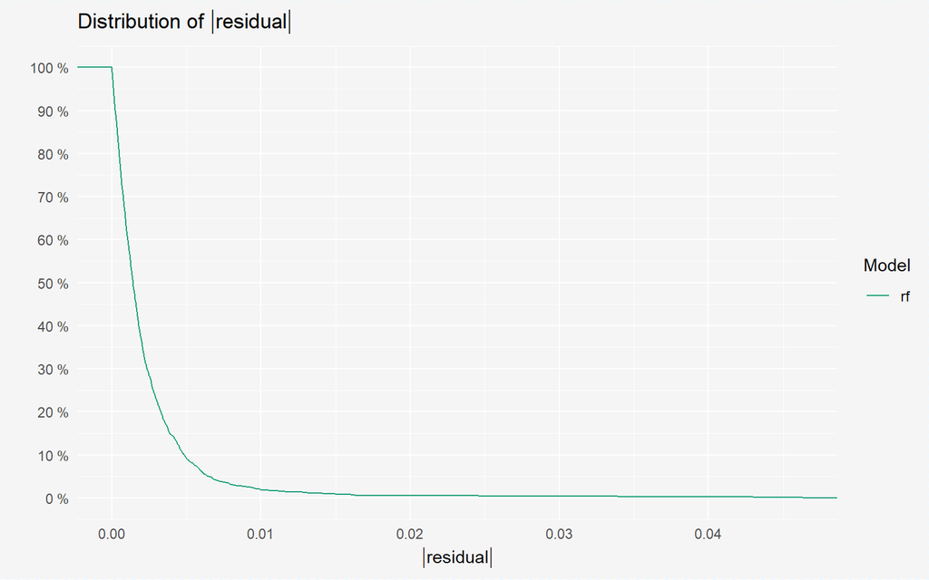

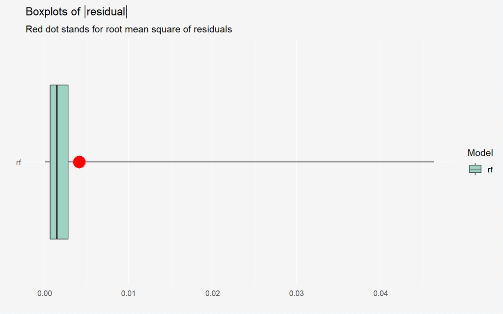

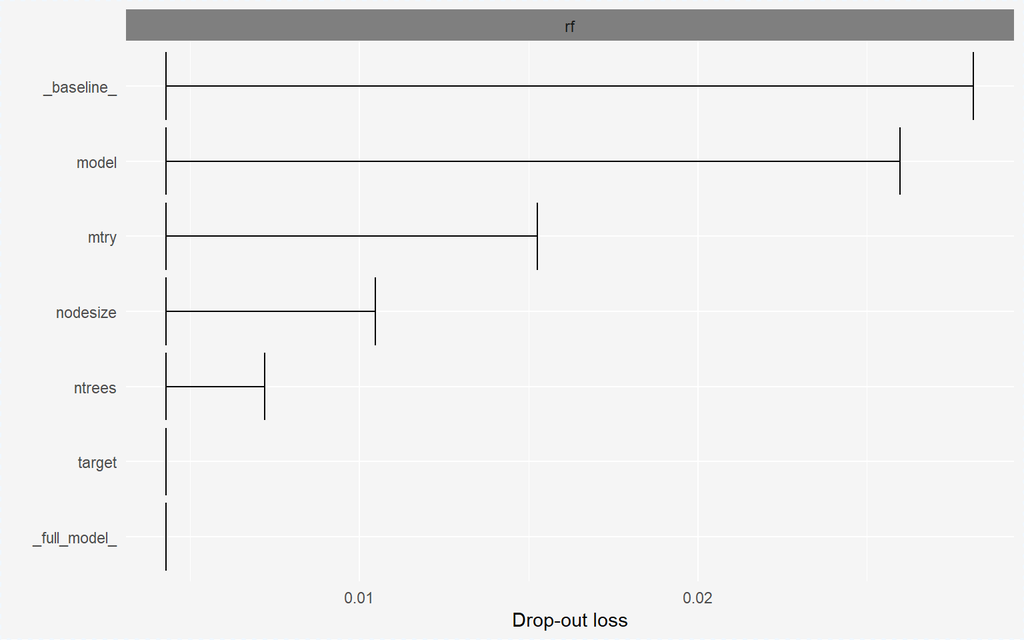

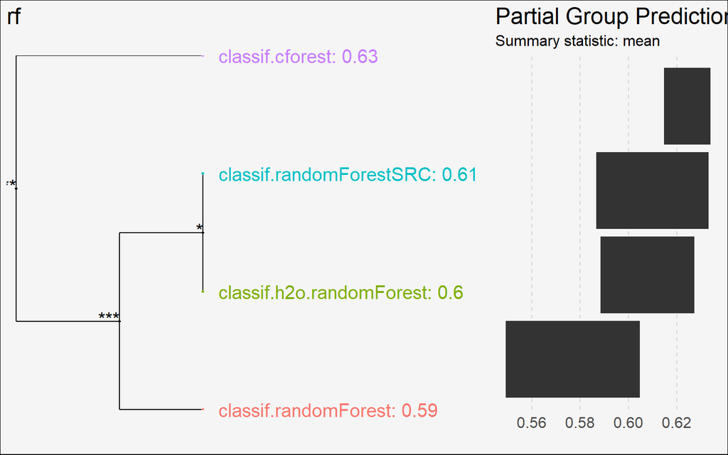

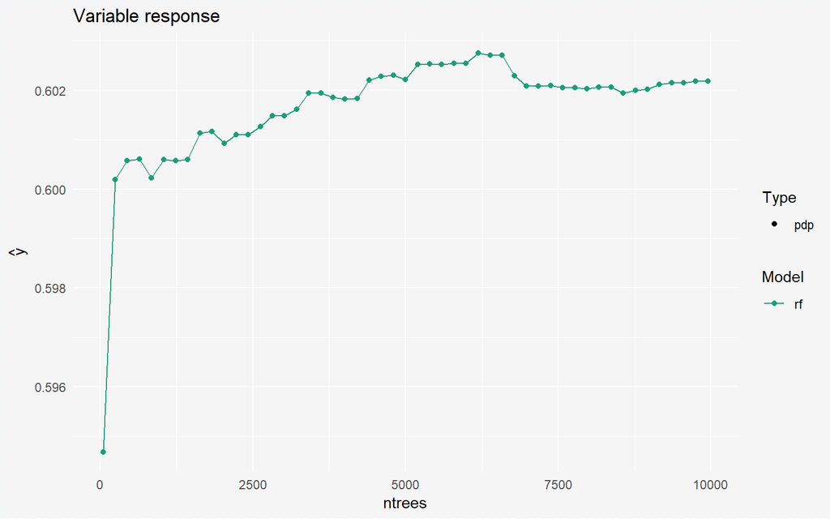

# Wnioski

- Pomysł według mnie jest ciekawe - warto go rozwijać
- mtry jest ważnijeszym parametrem niż ntrees
- Rodzaj zastosowanej implementacji lasóW losowych znacząco wpływa na wynik modelu

Szymon Maksymiuk